# Breast Cancer Diagnostics Analysis

Etini Levi

2026-04-15

## Brief Summary

This report analyzes the Wisconsin Breast Cancer (Diagnostic) dataset from https://www.kaggle.com/datasets/sarahvch/breast-cancer-wisconsin-prognostic-data-set to determine the relationship between cellular morphology and malignancy.

Using Logistic Regression, we achieved a classification accuracy of 92%.

We begin by examining the distribution of cell nuclei radius.

Larger nuclei are statistically more likely to be associated with malignant (M) samples.

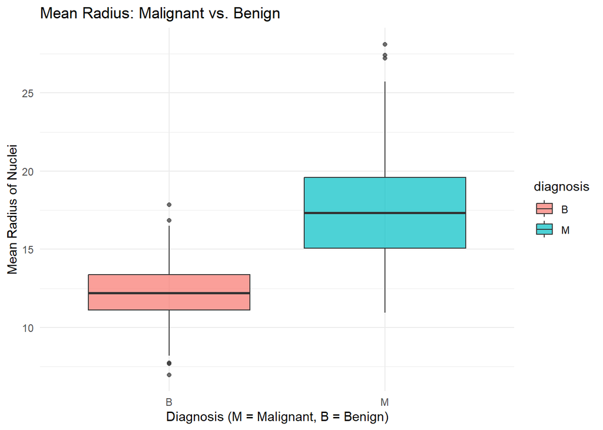

## Principal Component Analysis

The dataset had more then 30 features, so a PCA was performed to reduce the dataset in 2D space; PC1 and PC2 There was a clear separation between the two groups suggesting a strong biological signal.

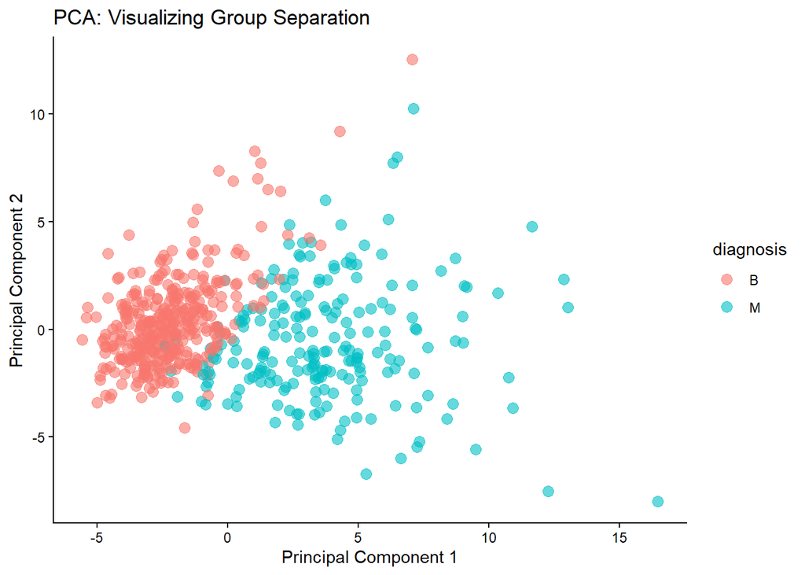

## Predictive Modeling

A Logistic Regression model was used to perform the predictive modeling. The focus were on three key features: Mean Radius, Mean Texture, and Mean Smoothness. The model was evaluated on a held-out test set (25% of the data) and the accuracy score was 92.9% The confusion matrix showed: 83 True Negative and 4 False Negative 6 False Positive and 49 True Positive.

```
##
## Call:
## glm(formula = diagnosis ~ radius_mean + texture_mean + smoothness_mean,
##     family = "binomial", data = train_data)
##
## Coefficients:
##                  Estimate Std. Error z value Pr(>|z|)
## (Intercept)     -41.42753    5.07315  -8.166 3.19e-16 ***
## radius_mean       1.37809    0.17713   7.780 7.24e-15 ***
## texture_mean      0.37137    0.06504   5.710 1.13e-08 ***
## smoothness_mean 144.42545   21.65328   6.670 2.56e-11 ***
## ---
## Signif. codes:  0 '***' 0.001 '**' 0.01 '*' 0.05 '.' 0.1 ' ' 1
##
## (Dispersion parameter for binomial family taken to be 1)
##
##     Null deviance: 562.88  on 425  degrees of freedom
## Residual deviance: 147.14  on 422  degrees of freedom
## AIC: 155.14
##
## Number of Fisher Scoring iterations: 8
```

```
##          Actual
## Predicted  B  M
##         B 83  4
##         M  6 49
```

## Conclusion

From this project, we have been able to perform EDA with the dataset, performed PCA to reduce 34 features into 2D, and then developed a Logistic Regression model to perform a predictive analytics of diagnosis based on radius_mean, texture_mean and smoothness_mean. The model had a 92.9% accuracy.